# FM Housing Price Prediction Project

Divine Gatebuka Iradukunda

2026-09-18

# Project Overview

This project uses Fargo-Moorhead housing data to develop a model that predicts the sold price of residential properties. The project includes data preparation, exploratory analysis, predictive modeling, model evaluation, and deployment through a Vetiver API and Shiny application.

## Data

The housing data for this project was provided through the DATA 470 course repository by Dr Gregory Tanner.

```r
housing <- read_csv("FM_Housing_2018_2022_clean.csv")
glimpse(housing)
```

```
## Rows: 15,770
## Columns: 41
## $ `Listing Agent`               <chr> "Shannon Barnum", "Mike Gillund", "Gary …
## $ `Start Date`                  <date> 2018-09-13, 2018-09-12, 2018-09-07, 201…
## $ `Sold Date`                   <date> 2018-11-09, 2018-11-05, 2018-10-26, 201…
## $ `Property Type`               <chr> "Residential", "Residential", "Residenti…
## $ `Book Section`                <chr> "Single Family Residence", "Single Famil…
## $ `Sub Type`                    <chr> "01", "01", "11", "01", "15", "15", "11"…
## $ `Original List Price`         <dbl> 214900, 242500, 297500, 325000, 178000, …
## $ `List Price`                  <dbl> 214900, 242500, 297500, 325000, 172500, …
## $ `Sold Price`                  <dbl> 214900, 240500, 287500, 319000, 172500, …
## $ City                          <chr> "Fargo", "Moorhead", "Fargo", "Fargo", "…
## $ `State/Province`              <chr> "ND", "MN", "ND", "ND", "MN", "ND", "ND"…
## $ County                        <chr> "Cass", "Clay", "Cass", "Cass", "Clay", …
## $ `Postal Code`                 <dbl> 58103, 56560, 58104, 58104, 56560, 58104…
```

[output cut: 28 more lines]

## Exploratory Data Analysis

Before building the predictive model, I examined the structure of the housing data and the distribution of the target variable, Sold Price.

```r
summary(housing$`Sold Price`)
```

```
##    Min. 1st Qu.  Median    Mean 3rd Qu.    Max.
##   17500  189900  239476  267936  314500 3241415
```

```r
housing |>
  summarise(
    across(
      everything(),
      ~ sum(is.na(.))
    )
  ) |>
  pivot_longer(
    cols = everything(),
    names_to = "variable",
    values_to = "missing"
  ) |>
  arrange(desc(missing))
```

```
## # A tibble: 41 × 2
##    variable             missing
##    <chr>                  <int>
##  1 Total Half Baths        6327
##  2 Max Bdrms - Same Flr    5820
##  3 Total 3/4 Baths         4844
##  4 Total Full Baths        1325
##  5 Laundry Location         910
##  6 Rooms                     72
##  7 Photo URL                 30
##  8 Sold Price Per/SqFt       27
##  9 List Price Per/SqFt       26
## 10 Subdivision                8
## # ℹ 31 more rows
```

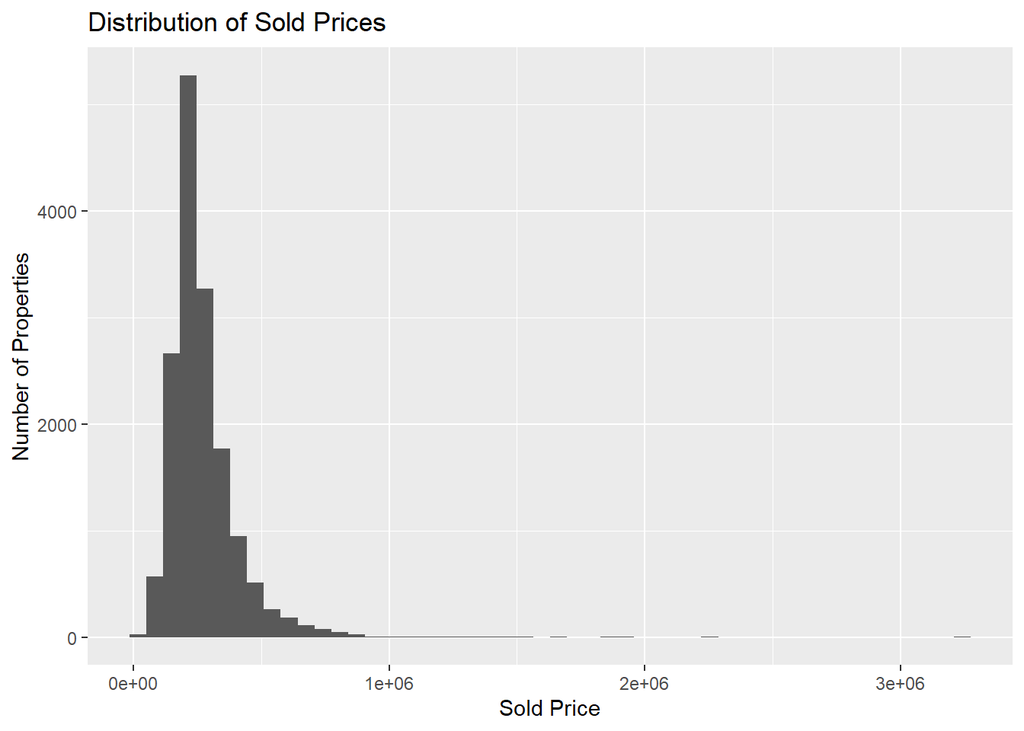

```r
ggplot(housing, aes(x = `Sold Price`)) +
  geom_histogram(bins = 50) +
  labs(
    title = "Distribution of Sold Prices",
    x = "Sold Price",
    y = "Number of Properties"
  )
```

## Interpretation

The distribution of Sold Price is right-skewed, with most properties selling at lower prices and a smaller number of properties selling for much higher prices. The long right tail shows that there are some high-priced properties in the dataset, with the maximum sold price being much higher than the typical property price.

This suggests that the model may need to account for the skewed distribution of housing prices when making predictions.

## Data Preparation

Before building the predictive model, I selected variables that could reasonably be used to predict a property’s sold price. I excluded variables that would reveal information about the sale.

```r
model_data <- housing |>
  select(
    `Sold Price`,
    `List Price`,
    `Original List Price`,
    `Total SqFt.`,
    `Year Built`,
    `Total Bedrooms`,
    `Total Bathrooms`,
    `Garage Stalls`,
    `Lot Size SqFt`,
    `Above Grade Finished Area`,
    `Below Grade Finished Area`,
    `Above Grade Unfinished Area`,
    `Below Grade Unfinished Area`,
    `Property Type`,
    `Style`,
    `City`,
    `County`,
    `Garage Type`
  ) |>
  rename(
    sold_price = `Sold Price`,
    list_price = `List Price`,
    original_list_price = `Original List Price`,
    total_sqft = `Total SqFt.`,
    year_built = `Year Built`,
    total_bedrooms = `Total Bedrooms`,
    total_bathrooms = `Total Bathrooms`,
    garage_stalls = `Garage Stalls`,
    lot_size_sqft = `Lot Size SqFt`,
    above_grade_finished = `Above Grade Finished Area`,
    below_grade_finished = `Below Grade Finished Area`,
    above_grade_unfinished = `Above Grade Unfinished Area`,
    below_grade_unfinished = `Below Grade Unfinished Area`,
    property_type = `Property Type`,
    style = Style,
    city = City,
    county = County,
    garage_type = `Garage Type`
  )

glimpse(model_data)
```

```
## Rows: 15,770
## Columns: 18
## $ sold_price             <dbl> 214900, 240500, 287500, 319000, 172500, 187500,…
## $ list_price             <dbl> 214900, 242500, 297500, 325000, 172500, 188000,…
## $ original_list_price    <dbl> 214900, 242500, 297500, 325000, 178000, 190000,…
## $ total_sqft             <dbl> 2352, 2700, 2710, 2842, 1672, 1736, 1768, 3913,…
## $ year_built             <dbl> 1951, 1979, 1994, 2010, 2005, 2010, 2000, 1990,…
## $ total_bedrooms         <dbl> 3, 4, 3, 5, 3, 3, 2, 3, 2, 3, 5, 4, 3, 6, 3, 3,…
## $ total_bathrooms        <dbl> 2, 3, 3, 4, 2, 2, 2, 3, 1, 2, 3, 4, 1, 4, 3, 2,…
## $ garage_stalls          <dbl> 2, 2, 2, 3, 2, 2, 2, 2, 1, 2, 2, 3, 2, 2, 2, 2,…
## $ lot_size_sqft          <dbl> 5200, 9600, 0, 15433, 4563, 4953, 70851, 16488,…
## $ above_grade_finished   <dbl> 1176, 1350, 1355, 1421, 836, 868, 1768, 2271, 9…
## $ below_grade_finished   <dbl> 300, 1350, 1300, 1421, 836, 868, 0, 0, 0, 550, …
## $ above_grade_unfinished <dbl> 0, 0, 0, 0, 0, 0, 0, 0, 0, 0, 0, 0, 0, 0, 0, 0,…
## $ below_grade_unfinished <dbl> 876, 0, 55, 0, 0, 0, 0, 1642, 0, 128, 150, 40, …
## $ property_type          <chr> "Residential", "Residential", "Residential", "R…
## $ style                  <chr> "1 Story", "Bi Level", "1 Story", "Bi Level", "…
## $ city                   <chr> "Fargo", "Moorhead", "Fargo", "Fargo", "Moorhea…
## $ county                 <chr> "Cass", "Clay", "Cass", "Cass", "Clay", "Cass",…
## $ garage_type            <chr> "A", "A", "A", "A", "A", "A", "A", "A", "D", "D…
```

### Why these?

We’re keeping a mix of:

**Property characteristics** - Total square footage - Year built - Bedrooms - Bathrooms - Garage - Lot size - Finished/unfinished areas

**Location** - City - County - Property type - Style

**Listing information** - List Price - Original List Price

This gives the model information that could reasonably be available when the property is being listed.

I excluded `Sold Price Per/SqFt` because it is calculated using the sold price and would cause target leakage. I also excluded variables such as `Sold Date` and `Days on Market` because they describe information that becomes available during or after the selling process rather than at the time of listing.

## Training/Testing Data

```r
set.seed(123)

train_index <- sample(
  seq_len(nrow(model_data)),
  size = 0.8 * nrow(model_data)
)

train_data <- model_data[train_index, ]
test_data <- model_data[-train_index, ]

nrow(train_data)
```

```
## [1] 12616
```

```r
nrow(test_data)
```

```
## [1] 3154
```

I split the prepared data into training and testing sets, using 80% of the observations for model training and 20% for evaluating model performance/testing. A random seed was used so that the same split can be reproduced.

## Model Development

I used a Random Forest regression model to predict the sold price of properties. Random Forest was selected because it can capture nonlinear relationships between housing characteristics and sold price while working with both numeric and categorical variables.

```r
set.seed(123)
model_data <- housing |>
  select(
    `Sold Price`,
    `List Price`,
    `Original List Price`,
    `Total SqFt.`,
    `Year Built`,
    `Total Bedrooms`,
    `Total Bathrooms`,
    `Garage Stalls`,
    `Lot Size SqFt`,
    `Above Grade Finished Area`,
    `Below Grade Finished Area`,
    `Above Grade Unfinished Area`,
    `Below Grade Unfinished Area`,
    `Property Type`,
    `Style`,
    `City`,
    `County`,
    `Garage Type`
  ) |>
  rename(
    sold_price = `Sold Price`,
    list_price = `List Price`,
    original_list_price = `Original List Price`,
    total_sqft = `Total SqFt.`,
    year_built = `Year Built`,
    total_bedrooms = `Total Bedrooms`,
    total_bathrooms = `Total Bathrooms`,
    garage_stalls = `Garage Stalls`,
    lot_size_sqft = `Lot Size SqFt`,
    above_grade_finished = `Above Grade Finished Area`,
    below_grade_finished = `Below Grade Finished Area`,
    above_grade_unfinished = `Above Grade Unfinished Area`,
    below_grade_unfinished = `Below Grade Unfinished Area`,
    property_type = `Property Type`,
    style = Style,
    city = City,
    county = County,
    garage_type = `Garage Type`
  )

glimpse(model_data)
```

```
## Rows: 15,770
## Columns: 18
## $ sold_price             <dbl> 214900, 240500, 287500, 319000, 172500, 187500,…
## $ list_price             <dbl> 214900, 242500, 297500, 325000, 172500, 188000,…
## $ original_list_price    <dbl> 214900, 242500, 297500, 325000, 178000, 190000,…
## $ total_sqft             <dbl> 2352, 2700, 2710, 2842, 1672, 1736, 1768, 3913,…
## $ year_built             <dbl> 1951, 1979, 1994, 2010, 2005, 2010, 2000, 1990,…
## $ total_bedrooms         <dbl> 3, 4, 3, 5, 3, 3, 2, 3, 2, 3, 5, 4, 3, 6, 3, 3,…
## $ total_bathrooms        <dbl> 2, 3, 3, 4, 2, 2, 2, 3, 1, 2, 3, 4, 1, 4, 3, 2,…
## $ garage_stalls          <dbl> 2, 2, 2, 3, 2, 2, 2, 2, 1, 2, 2, 3, 2, 2, 2, 2,…
## $ lot_size_sqft          <dbl> 5200, 9600, 0, 15433, 4563, 4953, 70851, 16488,…
## $ above_grade_finished   <dbl> 1176, 1350, 1355, 1421, 836, 868, 1768, 2271, 9…
## $ below_grade_finished   <dbl> 300, 1350, 1300, 1421, 836, 868, 0, 0, 0, 550, …
## $ above_grade_unfinished <dbl> 0, 0, 0, 0, 0, 0, 0, 0, 0, 0, 0, 0, 0, 0, 0, 0,…
## $ below_grade_unfinished <dbl> 876, 0, 55, 0, 0, 0, 0, 1642, 0, 128, 150, 40, …
## $ property_type          <chr> "Residential", "Residential", "Residential", "R…
## $ style                  <chr> "1 Story", "Bi Level", "1 Story", "Bi Level", "…
## $ city                   <chr> "Fargo", "Moorhead", "Fargo", "Fargo", "Moorhea…
## $ county                 <chr> "Cass", "Clay", "Cass", "Cass", "Clay", "Cass",…
## $ garage_type            <chr> "A", "A", "A", "A", "A", "A", "A", "A", "D", "D…
```

```r
# Random Forest Model
rf_model <- ranger(
  sold_price ~ .,
  data = train_data,
  num.trees = 500,
  importance = "impurity"
)

rf_model
```

```
## Ranger result
##
## Call:
##  ranger(sold_price ~ ., data = train_data, num.trees = 500, importance = "impurity")
##
## Type:                             Regression
## Number of trees:                  500
## Sample size:                      12616
## Number of independent variables:  17
## Mtry:                             4
## Target node size:                 5
## Variable importance mode:         impurity
## Splitrule:                        variance
## OOB prediction error (MSE):       464506717
## R squared (OOB):                  0.9716886
```

## Model Evaluation

After training the Random Forest model, I evaluated its predictions using the testing dataset, which was not used during model training.

```r
predictions <- predict(
  rf_model,
  data = test_data
)$predictions

head(predictions)
```

```
## [1] 284023.2 474150.1 140174.3 191710.4 171001.6 219136.3
```

```r
actual <- test_data$sold_price
predicted <- predictions

rmse <- sqrt(mean((actual - predicted)^2))

mae <- mean(abs(actual - predicted))

r_squared <- 1 - sum((actual - predicted)^2) /
  sum((actual - mean(actual))^2)

model_performance <- tibble(
  Metric = c("RMSE", "MAE", "R-squared"),
  Value = c(rmse, mae, r_squared)
)

model_performance
```

```
## # A tibble: 3 × 2
##   Metric        Value
##   <chr>         <dbl>
## 1 RMSE      35380.
## 2 MAE        8126.
## 3 R-squared     0.934
```

### Interpretation

The Random Forest model performed well on the testing data, with an R-squared value of 0.934. This means that the model explains approximately 93.4% of the variation in sold prices for the properties in the testing set.

The model had a mean absolute error (MAE) of approximately $8,126, meaning the average absolute difference between the predicted and actual sold prices was about $8,126.

The RMSE was approximately $35,380. This means the model’s prediction errors were around $35,380 on average, with larger errors having a bigger effect on the RMSE.

Overall, the results indicate that the model was able to predict sold prices reasonably well on properties it had not been trained on.

### Visualization

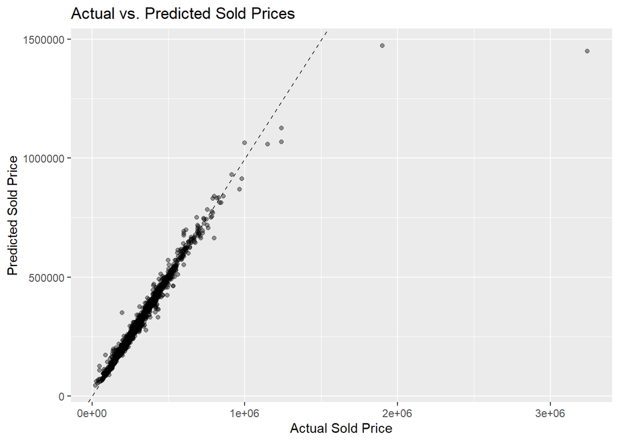

```r
prediction_results <- test_data |>
  select(sold_price) |>
  mutate(
    predicted_price = predictions
  )

ggplot(prediction_results, aes(x = sold_price, y = predicted_price)) +
  geom_point(alpha = 0.4) +
  geom_abline(
    intercept = 0,
    slope = 1,
    linetype = "dashed"
  ) +
  labs(
    title = "Actual vs. Predicted Sold Prices",
    x = "Actual Sold Price",
    y = "Predicted Sold Price"
  )
```

### Interpretation

Overall, the model’s predictions were fairly close to the actual prices for most homes, especially those selling below $1 million. However, the model had larger errors for some of the most expensive homes and underestimated their prices.

For example, one property sold for over $3 million, while the model predicted a price below $1.5 million.

### Vetiver Model

```r
v <- vetiver_model(
  rf_model,
  model_name = "fm-housing-price-model",
  prototype_data = train_data |>
    select(-sold_price) |>
    slice(1)
)
v
```

```
##
## ── fm-housing-price-model ─ <ranger> model for deployment
## A ranger regression model using 17 features
```

```r
saveRDS(v, "fm-housing-vetiver.rds")
```